# Your Document Title

### Part 4 - Inference:

#### Team’s elo to predict result

```r
new_sample <- select(sampleA, elo_i, opp_elo_i, game_location, game_result)
new_sample2<- new_sample
new_sample2$game_result <- as.numeric(new_sample2$game_result)


cor(new_sample2$game_result, new_sample2$elo_i)
```

```
## [1] 0.2371977
```

```r
model1 <- lm(game_result ~ elo_i, data=new_sample2)
summary(model1)
```

```
##
## Call:
## lm(formula = game_result ~ elo_i, data = new_sample2)
##
## Residuals:
##     Min      1Q  Median      3Q     Max
## -0.8595 -0.4619 -0.2420  0.4770  0.9075
##
## Coefficients:
##               Estimate Std. Error t value Pr(>|t|)
## (Intercept) -9.763e-02  2.527e-02  -3.864 0.000112 ***
## elo_i        1.056e-03  1.685e-05  62.671  < 2e-16 ***
## ---
## Signif. codes:  0 '***' 0.001 '**' 0.01 '*' 0.05 '.' 0.1 ' ' 1
##
## Residual standard error: 0.4854 on 65881 degrees of freedom
## Multiple R-squared:  0.05626,    Adjusted R-squared:  0.05625
## F-statistic:  3928 on 1 and 65881 DF,  p-value: < 2.2e-16
```

```r
model1a <- glm(game_result ~ elo_i, data=new_sample, family = "binomial")
summary(model1a)
```

```
##
## Call:
## glm(formula = game_result ~ elo_i, family = "binomial", data = new_sample)
##
## Deviance Residuals:
##     Min       1Q   Median       3Q      Max
## -1.8519  -1.1090  -0.7608   1.1373   1.9429
##
## Coefficients:
##               Estimate Std. Error z value Pr(>|z|)
## (Intercept) -6.749e+00  1.128e-01  -59.82   <2e-16 ***
## elo_i        4.460e-03  7.511e-05   59.38   <2e-16 ***
## ---
## Signif. codes:  0 '***' 0.001 '**' 0.01 '*' 0.05 '.' 0.1 ' ' 1
##
## (Dispersion parameter for binomial family taken to be 1)
##
##     Null deviance: 91244  on 65882  degrees of freedom
## Residual deviance: 87438  on 65881  degrees of freedom
## AIC: 87442
##
## Number of Fisher Scoring iterations: 4
```

There is low correlation between game result and team elo and the estimate for elo_i is very low indicating that it does not have much effect on the game result. However small this estimate is, it is still a statistically significant predictor.

*Conditions Check*

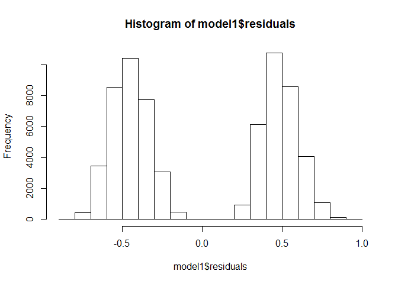

```r
hist(model1$residuals)
```

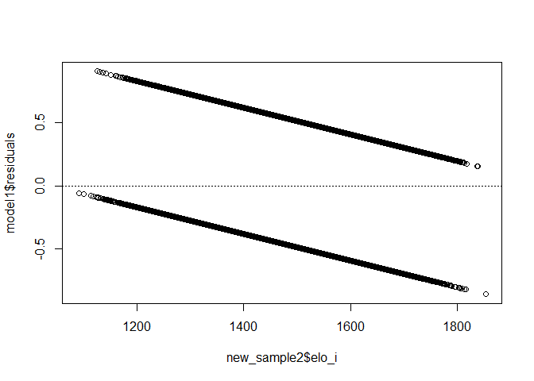

```r
plot(model1$residuals ~ new_sample2$elo_i)
abline(h=0, lty=3)
```

```r
cor(new_sample2$game_result, new_sample2$opp_elo_i)
```

```
## [1] -0.2291953
```

```r
model2 <- lm(game_result ~ opp_elo_i, data=new_sample2)
summary(model2)
```

```
##
## Call:
## lm(formula = game_result ~ opp_elo_i, data = new_sample2)
##
## Residuals:
##     Min      1Q  Median      3Q     Max
## -0.8737 -0.4548 -0.2768  0.4872  0.8613
##
## Coefficients:
##               Estimate Std. Error t value Pr(>|t|)
## (Intercept)  3.008e+00  2.533e-02  118.76   <2e-16 ***
## opp_elo_i   -1.021e-03  1.689e-05  -60.44   <2e-16 ***
## ---
## Signif. codes:  0 '***' 0.001 '**' 0.01 '*' 0.05 '.' 0.1 ' ' 1
##
## Residual standard error: 0.4864 on 65881 degrees of freedom
## Multiple R-squared:  0.05253,    Adjusted R-squared:  0.05252
## F-statistic:  3653 on 1 and 65881 DF,  p-value: < 2.2e-16
```

```r
model2a <- glm(game_result ~ opp_elo_i, data = new_sample, family = "binomial")
summary(model2a)
```

```
##
## Call:
## glm(formula = game_result ~ opp_elo_i, family = "binomial", data = new_sample)
##
## Deviance Residuals:
##     Min       1Q   Median       3Q      Max
## -1.8751  -1.0985  -0.8137   1.1542   1.8513
##
## Coefficients:
##               Estimate Std. Error z value Pr(>|z|)
## (Intercept)  6.329e+00  1.117e-01   56.67   <2e-16 ***
## opp_elo_i   -4.284e-03  7.455e-05  -57.47   <2e-16 ***
## ---
## Signif. codes:  0 '***' 0.001 '**' 0.01 '*' 0.05 '.' 0.1 ' ' 1
##
## (Dispersion parameter for binomial family taken to be 1)
##
##     Null deviance: 91244  on 65882  degrees of freedom
## Residual deviance: 87704  on 65881  degrees of freedom
## AIC: 87708
##
## Number of Fisher Scoring iterations: 4
```

```r
#cor(new_sample2$game_result, new_sample2$game_location)

model3 <- lm(game_result ~ game_location, data=new_sample2)
summary(model3)
```

```
##
## Call:
## lm(formula = game_result ~ game_location, data = new_sample2)
##
## Residuals:
##     Min      1Q  Median      3Q     Max
## -0.6253 -0.3790 -0.3790  0.3747  0.6210
##
## Coefficients:
##                Estimate Std. Error t value Pr(>|t|)
## (Intercept)    1.379033   0.002472  557.76   <2e-16 ***
## game_locationH 0.246226   0.003830   64.28   <2e-16 ***
## ---
## Signif. codes:  0 '***' 0.001 '**' 0.01 '*' 0.05 '.' 0.1 ' ' 1
##
## Residual standard error: 0.4847 on 65881 degrees of freedom
## Multiple R-squared:  0.05902,    Adjusted R-squared:  0.05901
## F-statistic:  4132 on 1 and 65881 DF,  p-value: < 2.2e-16
```

```r
model3a <- glm(game_result ~ game_location, data=new_sample, family = "binomial")
summary(model3a)
```

```
##
## Call:
## glm(formula = game_result ~ game_location, family = "binomial",
##     data = new_sample)
##
## Deviance Residuals:
##     Min       1Q   Median       3Q      Max
## -1.4011  -0.9762  -0.9762   0.9691   1.3929
##
## Coefficients:
##                Estimate Std. Error z value Pr(>|z|)
## (Intercept)    -0.49365    0.01051  -46.95   <2e-16 ***
## game_locationH  1.00559    0.01631   61.65   <2e-16 ***
## ---
## Signif. codes:  0 '***' 0.001 '**' 0.01 '*' 0.05 '.' 0.1 ' ' 1
##
## (Dispersion parameter for binomial family taken to be 1)
##
##     Null deviance: 91244  on 65882  degrees of freedom
## Residual deviance: 87320  on 65881  degrees of freedom
## AIC: 87324
##
## Number of Fisher Scoring iterations: 4
```

### Part 5 - Conclusion:

It seems as though the game_location has most impact on game result. This would mean that even though elo is used as a ranking mechanism for NBA team, the traditional home court advantage is still a better predictor of the game result.

### References:

The Complete History of the NBA by Ruben Fischer-Baum and Nate Silver (https://projects.fivethirtyeight.com/complete-history-of-the-nba/#spurs)